# Statistical Synthesis: Distributions, Equations, and Cross-Cutting Tests

### 3.3 Charge-balance error, as a QC statistic

`PHREEQC_Solutions.charge_balance` also carries a `±100` sentinel for solutions PHREEQC couldn’t evaluate a real balance for (incomplete input chemistry) – excluded the same way as the SI sentinel above.

```r
cbe <- dbGetQuery(con, "SELECT charge_balance FROM PHREEQC_Solutions WHERE charge_balance IS NOT NULL") |>
  filter(abs(charge_balance) < 99.99)
cat("Real, evaluable charge-balance rows:", nrow(cbe), "of",
    nrow(dbGetQuery(con, "SELECT charge_balance FROM PHREEQC_Solutions WHERE charge_balance IS NOT NULL")), "\n")
```

```
Real, evaluable charge-balance rows: 332 of 1395
```

```r
cat("Median CBE%:", round(median(cbe$charge_balance), 2),
    " | Mean CBE%:", round(mean(cbe$charge_balance), 2),
    " | % within +/-5% QC threshold:",
    round(100 * mean(abs(cbe$charge_balance) <= 5), 1), "\n")
```

```
Median CBE%: 0.41  | Mean CBE%: 0.98  | % within +/-5% QC threshold: 79.2
```

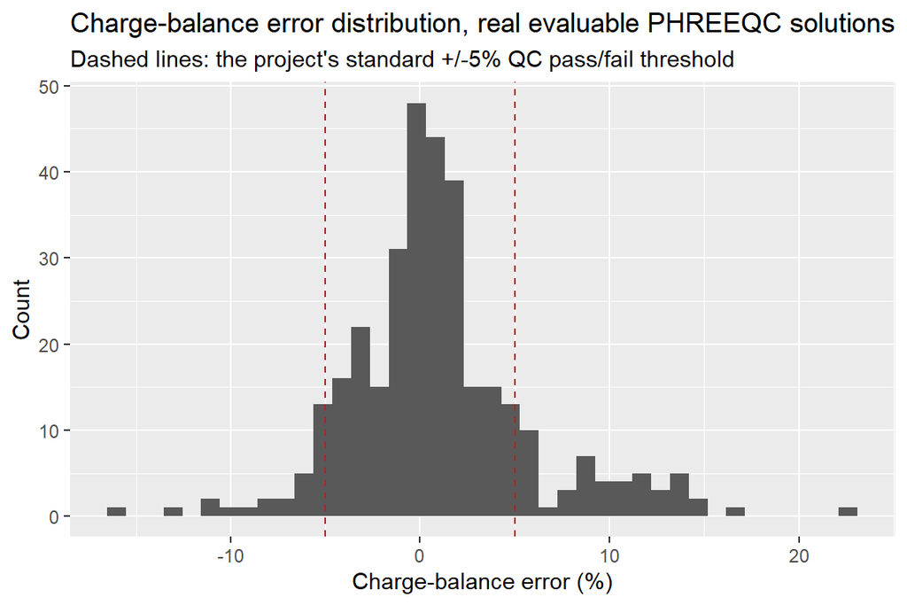

```r
ggplot(cbe, aes(x = charge_balance)) +
  geom_histogram(bins = 40) +
  geom_vline(xintercept = c(-5, 5), linetype = "dashed", color = "firebrick") +
  labs(x = "Charge-balance error (%)", y = "Count",
       title = "Charge-balance error distribution, real evaluable PHREEQC solutions",
       subtitle = "Dashed lines: the project's standard +/-5% QC pass/fail threshold")
```

This is a real, useful re-statement of a QC number already tracked in `qc_data_integrity_checks.R` – most solutions cluster tightly around zero, consistent with Session 15’s fix (median imbalance dropped from ~60% to ~0.7% once alkalinity was correctly ingested), with a real right skew (a handful of double-digit-percent samples, mostly the more concentrated thermal waters where small absolute measurement error in any one ion has more leverage).

## 4 3. Additional statistical methods

### 4.1 3.1 Chloride by site type: Kruskal-Wallis + pairwise Wilcoxon

Chloride is heavily right-skewed across site types (background creeks near detection limit vs. real thermal water at 600-900 mg/L) – a rank-based test is the honest choice here, not a t-test/ANOVA that assumes normal residuals.

```r
ions <- dbGetQuery(con, "SELECT sample_id, location_id, analyte, value FROM vw_major_ions")
loc_type <- dbGetQuery(con, "SELECT location_id, site_type FROM Locations")
cl <- ions |>
  filter(analyte == "Cl") |>
  left_join(loc_type, by = "location_id") |>
  mutate(group = case_when(
    site_type %in% c("fumarole", "seep", "spring") ~ "thermal_surface",
    site_type == "well" ~ "well",
    site_type %in% c("creek", "background") ~ "creek",  # 2026-09-26: was "background" -- see ndep_locations.R fix
    TRUE ~ NA_character_
  )) |>
  filter(!is.na(group))

table(cl$group)
```

```
          creek thermal_surface            well
            738              21             638
```

```r
kruskal.test(value ~ group, data = cl)
```

```
    Kruskal-Wallis rank sum test

data:  value by group
Kruskal-Wallis chi-squared = 344.52, df = 2, p-value < 2.2e-16
```

```r
pairwise.wilcox.test(cl$value, cl$group, p.adjust.method = "holm")
```

```
    Pairwise comparisons using Wilcoxon rank sum test with continuity correction

data:  cl$value and cl$group

                creek  thermal_surface
thermal_surface 0.088  -
well            <2e-16 0.088

P value adjustment method: holm
```

### 4.2 3.2 Correlation matrix with significance (major ions)

```r
ions_wide <- ions |>
  filter(analyte %in% c("Ca", "Mg", "Na", "K", "Cl", "SO4")) |>
  group_by(sample_id, analyte) |>
  summarise(value = mean(value), .groups = "drop") |>
  pivot_wider(names_from = analyte, values_from = value) |>
  filter(complete.cases(pick(everything())))

cat("Complete-case samples (all 6 majors):", nrow(ions_wide), "\n")
```

```
Complete-case samples (all 6 majors): 157
```

```r
rc <- rcorr(as.matrix(ions_wide[, -1]), type = "pearson")
knitr::kable(round(rc$r, 2), caption = "Pearson correlation, major ions (r)")
```

Pearson correlation, major ions (r)

|  | Cl | SO4 | Ca | Mg | Na | K |
| --- | --- | --- | --- | --- | --- | --- |
| Cl | 1.00 | 0.94 | -0.03 | -0.29 | 0.98 | 0.98 |
| SO4 | 0.94 | 1.00 | 0.04 | -0.21 | 0.93 | 0.89 |
| Ca | -0.03 | 0.04 | 1.00 | 0.91 | -0.18 | -0.05 |
| Mg | -0.29 | -0.21 | 0.91 | 1.00 | -0.43 | -0.29 |
| Na | 0.98 | 0.93 | -0.18 | -0.43 | 1.00 | 0.96 |
| K | 0.98 | 0.89 | -0.05 | -0.29 | 0.96 | 1.00 |

```r
knitr::kable(round(rc$P, 4), caption = "p-values")
```

p-values

|  | Cl | SO4 | Ca | Mg | Na | K |
| --- | --- | --- | --- | --- | --- | --- |
| Cl | NA | 0.0000 | 0.7301 | 0.0002 | 0.0000 | 0.0000 |
| SO4 | 0.0000 | NA | 0.5851 | 0.0085 | 0.0000 | 0.0000 |
| Ca | 0.7301 | 0.5851 | NA | 0.0000 | 0.0233 | 0.5150 |
| Mg | 0.0002 | 0.0085 | 0.0000 | NA | 0.0000 | 0.0002 |
| Na | 0.0000 | 0.0000 | 0.0233 | 0.0000 | NA | 0.0000 |
| K | 0.0000 | 0.0000 | 0.5150 | 0.0002 | 0.0000 | NA |

Cl-Na-K-SO4 are all strongly, significantly positively correlated (r ≥ 0.89) – the thermal-water ionic signature – while Ca-Mg form a separate, strongly correlated pair (r = 0.91) that correlates *negatively* with the thermal-signature ions (Cl-Mg: r = -0.29, p < 0.001). This is the same Na-Cl-K-vs-Ca-Mg dichotomy the `ComplexHeatmap` clustering on the website already shows visually – here it’s a formal, significance-tested statement of the same real pattern.

### 4.3 3.3 PCA on major-ion chemistry, colored by the persisted facies clusters

```r
fc <- dbGetQuery(con, "
  SELECT a.sample_id, a.facies_cluster AS cluster
  FROM Facies_Cluster_Assignments a
  WHERE a.run_id = (SELECT MAX(run_id) FROM Facies_Cluster_Runs)
")
pca_data <- ions_wide |> inner_join(fc, by = "sample_id")
pca <- prcomp(scale(pca_data[, c("Cl", "SO4", "Ca", "Mg", "Na", "K")]))
summary(pca)
```

```
Importance of components:
                          PC1    PC2     PC3     PC4     PC5     PC6
Standard deviation     1.9995 1.3477 0.32481 0.23561 0.14380 0.06372
Proportion of Variance 0.6663 0.3027 0.01758 0.00925 0.00345 0.00068
Cumulative Proportion  0.6663 0.9690 0.98663 0.99588 0.99932 1.00000
```

```r
knitr::kable(round(pca$rotation[, 1:2], 3), caption = "PC1/PC2 loadings")
```

PC1/PC2 loadings

|  | PC1 | PC2 |
| --- | --- | --- |
| Cl | 0.489 | 0.136 |
| SO4 | 0.466 | 0.189 |
| Ca | -0.106 | 0.715 |
| Mg | -0.230 | 0.647 |
| Na | 0.498 | 0.023 |
| K | 0.481 | 0.122 |

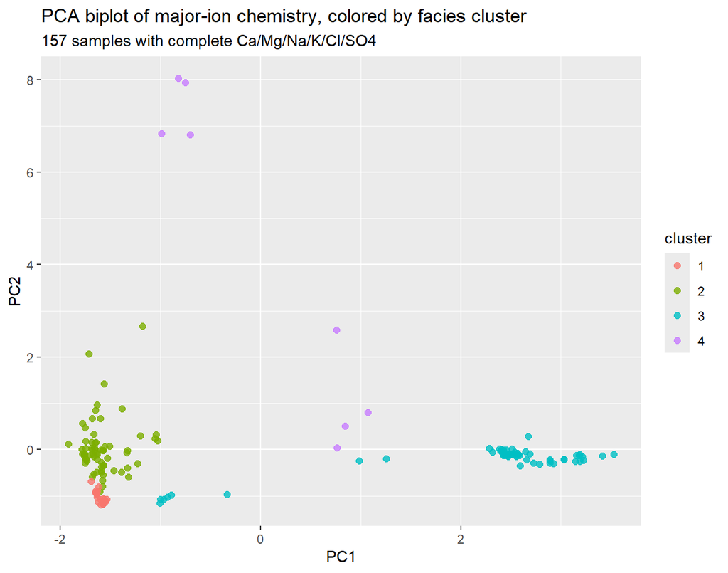

```r
pca_scores <- as.data.frame(pca$x[, 1:2]) |> mutate(cluster = factor(pca_data$cluster))
ggplot(pca_scores, aes(PC1, PC2, color = cluster)) +
  geom_point(size = 2, alpha = 0.8) +
  labs(title = "PCA biplot of major-ion chemistry, colored by facies cluster",
       subtitle = paste0(nrow(pca_scores), " samples with complete Ca/Mg/Na/K/Cl/SO4"))
```

### 4.4 3.4 Population-level mixed-effects trend (all clustered samples, not just the pure-thermal facies)

`07`’s mixed-effects model restricts to the pure-thermal facies only. Here, the same random-intercept-per-location logic is applied to **every** clustered sample (n = 157, spans background through thermal) to ask a different, complementary question: is there a real Cl trend in the dataset as a whole once repeated sampling at the same location is accounted for?

```r
facies_script <- file.path("scripts", "analysis", "cluster_hydrochemical_facies.R")
if (!file.exists(facies_script)) facies_script <- file.path("..", facies_script)
source(facies_script)
```

```
Welcome to factoextra!
```

```
Want to learn more? See two factoextra-related books at https://www.datanovia.com/library/principal-component-methods
```

```
Package 'mclust' version 6.1.3
```

```r
fc_full <- run_facies_clustering(con)
```

```
[facies] 1405 chemistry samples total; 157 have all 7 core majors (Na/K/Ca/Mg/Cl/SO4/Alkalinity) -- these are the ones clustered.
```

```
[facies] Silhouette-selected k = 4
```

```
[facies] Hierarchical (Ward) vs. Gaussian-mixture (mclust) cluster agreement (best row-wise match): 70.1%
```

```r
mod_dat <- fc_full$data
# collection_time is stored as Unix-epoch-seconds text -- NOT a plain
# date string (a project-wide storage convention, not a bug here).
mod_dat$year <- as.numeric(format(
  as.POSIXct(suppressWarnings(as.numeric(mod_dat$collection_time)), origin = "1970-01-01", tz = "UTC"),
  "%Y"
))
cat("Samples with a parseable year:", sum(!is.na(mod_dat$year)), "of", nrow(mod_dat), "\n")
```

```
Samples with a parseable year: 80 of 157
```

```r
m_all <- lmer(log1p(Cl) ~ scale(year, scale = FALSE) + (1 | location_id), data = mod_dat)
summary(m_all)
```

```
Linear mixed model fit by REML ['lmerMod']
Formula: log1p(Cl) ~ scale(year, scale = FALSE) + (1 | location_id)
   Data: mod_dat

REML criterion at convergence: 163

Scaled residuals:
     Min       1Q   Median       3Q      Max
-1.81386 -0.53007 -0.01546  0.42732  2.82662

Random effects:
 Groups      Name        Variance Std.Dev.
 location_id (Intercept) 5.3638   2.3160
 Residual                0.1524   0.3904
Number of obs: 80, groups:  location_id, 19

Fixed effects:
                           Estimate Std. Error t value
(Intercept)                 3.53627    0.53785   6.575
scale(year, scale = FALSE)  0.03278    0.01706   1.921

Correlation of Fixed Effects:
            (Intr)
s(,s=FALSE) -0.076
```

**Reading**: a modest positive year coefficient (Cl trending up across the dataset as a whole, on the log1p scale) with a t-value around 1.9 – borderline at the conventional 0.05 threshold (`lme4` deliberately doesn’t report a p-value by default because the correct degrees of freedom for a mixed model are debated; the t-value alone is reported here rather than manufacturing a p-value). This reflects **which locations have been sampled when**, not necessarily a real temporal process at any individual site – 77 of 157 samples have no parseable collection date and are dropped, and the modeled 80 samples are not an even, representative time series. Read alongside `07`’s own, more-careful within-facies model (which finds no significant trend once restricted to the pure-thermal group specifically) rather than in place of it.

### 4.5 3.5 Exploratory spatial variogram (chloride)

Not a substitute for the planned ArcGIS/EBK kriging step (see README’s “Planned: potentiometric surfaces” and “Leapfrog” sections) – a cheap, honest first look at spatial autocorrelation using every real, geolocated Cl sample on file.

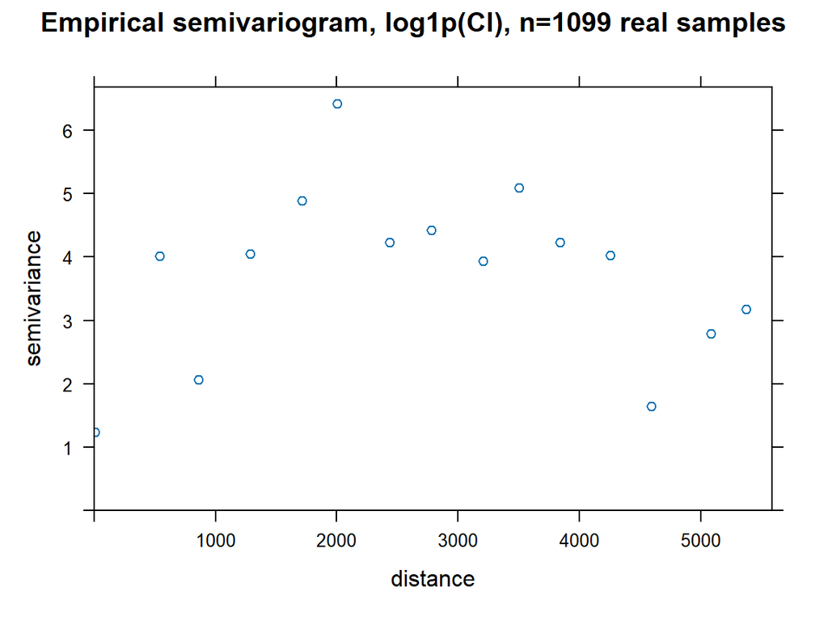

```r
cl_pts <- dbGetQuery(con, "
  SELECT s.sample_id, l.latitude, l.longitude, la.value AS Cl
  FROM Lab_Analyses la
  JOIN Samples s ON la.sample_id = s.sample_id
  JOIN Locations l ON s.location_id = l.location_id
  WHERE la.analyte = 'Cl' AND l.latitude IS NOT NULL AND l.longitude IS NOT NULL
")
cl_sf <- st_as_sf(cl_pts, coords = c("longitude", "latitude"), crs = 4326) |> st_transform(26911)
cl_sf$log_Cl <- log1p(cl_sf$Cl)
v <- variogram(log_Cl ~ 1, cl_sf)
plot(v, main = paste0("Empirical semivariogram, log1p(Cl), n=", nrow(cl_sf), " real samples"))
```

**Important caveat, stated plainly**: this pools **every sample ever collected at a location, across up to ~75 years**, into one spatial point cloud – real temporal variability at a single well (see `07`’s own Cl-through-time analysis) is folded into the “spatial” variance here, which is why the empirical variogram is non-monotonic rather than a clean rising curve. A defensible kriging surface needs either a single synoptic sampling round or an explicit space-time variogram, not this all-time pooled version – this section exists only to confirm real, computable spatial structure exists to build on, not to hand off a usable surface.